# Análise de Resíduos em Modelos de Regressão Linear

2019-09-05

O modelo de regressão linear é bastante usado na predição de variáveis contínuas, onde há uma ou mais variáveis independentes buscando mapear o comportamento de uma variável dependente. O modelo é bastante simples e lembro ser um dos primeiros a ser ensinado nas aulas de econometria. Porém, apesar de sua simplicidade, é preciso se atentar a alguns detalhes sobre suas premissas para que os resultados deste modelo possam ser usados para a tomada de decisão.

Tendo estas premissas atendidas, o modelo pode gerar conclusões confiáveis. Neste post eu vou desenvolver alguns modelos de regressão linear para testar as premissas **iii** e **iv** que tratam dos resíduos, para ver alguns casos práticos.

Para começar, vamos trazer os pacotes necessários para execução das funções no R:

```r
library(tidyverse)
library(lmtest)
library(corrplot)
library(readxl)
```

Também vou criar uma função para facilitar a padronização dos gráficos que serão gerados.

```r
theme_graph <- function(){
  theme(
    plot.title = element_text(size = 16),
    plot.subtitle = element_text(size = 12),
    plot.caption = element_text(face = "italic", size = 9),
    axis.text = element_text(size = 9),
    axis.title = element_text(face = "italic", size = 9),
    strip.background = element_rect(fill = "grey"),
    strip.text = element_text(face = "bold"),
    legend.title = element_blank(),
    legend.position = "bottom",
    panel.grid.major = element_line(
        rgb(198, 198, 216, maxColorValue = 255),
        linetype = "dotted"),
    panel.grid.minor = element_line(
        rgb(198, 198, 216, maxColorValue = 255),
        linetype = "dotted"),
    panel.background = element_rect(fill = "#FEFDFF")
  )
}
```

Este exemplo foi passado na minha aula de econometria em 2017. Na época o exercício foi realizado com o software **EViews**, por sorte eu guardei os dados e agora posso refazer o problema com mais facilidade com o uso do R.

No exercício, há a variável independente (X) sendo o preço da cana de açúcar e a variável dependente (Y) sendo a área plantada de cana de açúcar (representando uma proxy para a oferta do produto). O objetivo deste modelo é tentar quantificar a elasticidade da oferta em função do preço, ou seja, quantificar quão sensível é a oferta da cana de açúcar quando ocorre uma variações em seu preço. Os dados deste exercício estão no meu repositório do Github, vamos trazê-los com o comando abaixo, salvando-os na variável df (a.k.a data.frame):

```r
df <- read.csv(file = "https://raw.githubusercontent.com/FranciscoPiccolo/franciscopiccolo.github.io/master/datasets/2019-09-05-residual_analysis_on_linear_regression_models/dataset_1.csv", sep = ";", dec = ",")

dim(df)
```

```
## [1] 34  3
```

Com a função **dim** podemos ver a dimensão deste dataset, com 34 registros e 3 colunas.

The data set for this example has 34 rows, with planted area and suggarcane price fields. Vamos ver uma amostra dos dados.

```r
df[sample(nrow(df),5), ] %>%
    as_tibble()
```

| period | area | price |
| --- | --- | --- |
| 12 | 80 | 0.145585 |
| 2 | 71 | 0.114894 |
| 17 | 250 | 0.380952 |
| 27 | 97 | 0.401437 |
| 10 | 70 | 0.195946 |

O modelo de regressão linear para este cenário será desenvolvido de acordo com a fórmula abaixo:

$$lnY_t = \beta_0+\beta_1 (lnX_t) + \mu_t$$

Onde:

$Y_t$ = Área plantada após a transformação com log natural (e)

$X_t$ = Preço da cana de açúcar também após a transformação com log natural

$\beta_0$ = Intercepto

$\beta_1$ = Inclinação

$\mu_t$ = Resíduos

Os dados precisam ter a aplicação do log natural, pois esta transformação faz com que as variações entre os períodos possam ser interpretadas como variações percentuais, e isso é necessário por conta de que a elasticidade é quantificada em termos percentuais. Esta característica ocorre apenas na transformação com logarítmo natural, se a transformação fosse feita com outros logs, a interpretação não seria válida.

O gráfico abaixo irá mostrar o comportamento das variáveis do dataset, bem como a curva de regressão linear, antes de aplicar a transformação log natural.

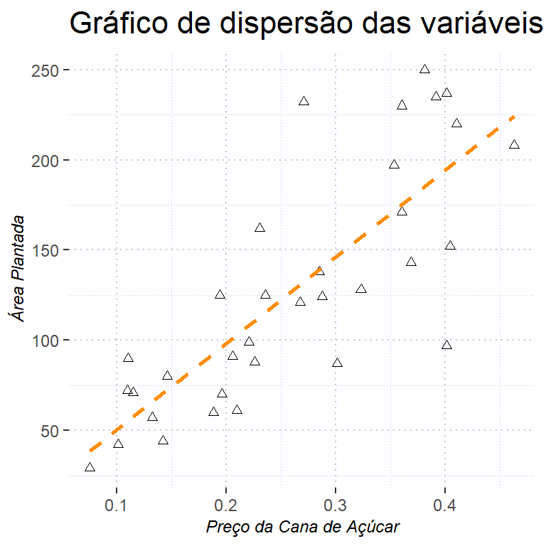

```r
df %>%
  ggplot()+
  geom_point(mapping = aes(x = price, y = area), shape = 2)+
  geom_smooth(mapping = aes(x = price, y = area),
              method = "lm",
              formula = y ~ x,
              se = F,
              lty = 2,
              color = "dark orange")+
  theme_graph()+
  labs(title = "Gráfico de dispersão das variáveis",
       x = "Preço da Cana de Açúcar",
       y = "Área Plantada")
```

Podemos ver que há uma relação entre o preço do produto e sua oferta. Agora vamos aplicar o log natural no modelo de regressão. Para isso, o R nos fornece duas opções:

- Ajustar as variáveis no dataset e construir o modelo usando as variáveis ajustadas.
- Construir o modelo e indicar “dentro dele” que é necessário fazer a transformação antes de computar os resultados.

Vamos ver na prática como cada opção pode ser usada. O resultado final será idêntico.

Primeiro vou criar duas variáveis com os resultados dos dois métodos:

```r
# Método 1, criando novos campos no dataset com a transformação log (e)
first_method <-
  df %>%
  mutate(area_log = log(area),
         price_log = log(price)) %>%
  lm(formula = area_log ~ price_log)

second_method <-
  df %>%
  lm(formula = log(area) ~ log(price))
```

Com as duas variáveis criadas, vamos criar uma tabela comparando os principais resultados dos modelos:

```r
data.frame("1º Método" = c(first_method$coefficients),
           "2º Método" = c(second_method$coefficients))
```

|  | X1º.Método | X2º.Método |
| --- | --- | --- |
| (Intercept) | 6.1113284 | 6.1113284 |
| price_log | 0.9705823 | 0.9705823 |

O resultado é estatisticamente significativo, visto que tanto o intercepto quanto a inclinação apresentam um valor-p baixo. Veja abaixo estes valores bem como o R².

```r
second_method %>% summary()
```

```
##
## Call:
## lm(formula = log(area) ~ log(price), data = .)
##
## Residuals:
##      Min       1Q   Median       3Q      Max
## -0.65076 -0.18823 -0.03096  0.24914  0.60492
##
## Coefficients:
##             Estimate Std. Error t value Pr(>|t|)
## (Intercept)   6.1113     0.1686  36.254  < 2e-16 ***
## log(price)    0.9706     0.1106   8.773 5.03e-10 ***
## ---
## Signif. codes:  0 '***' 0.001 '**' 0.01 '*' 0.05 '.' 0.1 ' ' 1
##
## Residual standard error: 0.3088 on 32 degrees of freedom
## Multiple R-squared:  0.7063, Adjusted R-squared:  0.6972
## F-statistic: 76.97 on 1 and 32 DF,  p-value: 5.031e-10
```

Apesar destes dados mostrarem que a reta se ajustou bem aos dados e que o modelo consegue explicar ~70% da variação na variável dependente, é preciso anda analisar os resíduos para poder ter confiança no resultado para fazer projeções. No gráfico abaixo, vamos ver como se distribui os resíduos do modelo.

```r
model_residuals <-
  data.frame(values = second_method$residuals)
```

Eu opto primeiro por analisar um histograma dos reísduos, pois ele indicará se a distribuição se assemelha a uma distribuição normal. Vamos ver isso no gráfico abaixo.

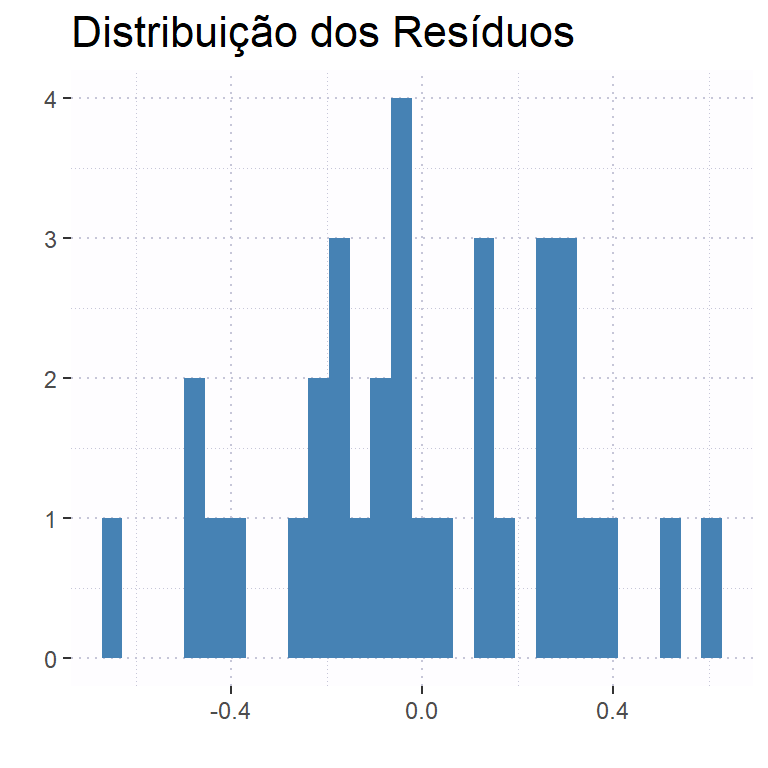

```r
# Histogram
model_residuals %>%
  ggplot()+
  geom_histogram(mapping = aes(x = values), fill = "steel blue")+
  theme_graph()+
  labs(title = "Distribuição dos Resíduos",
       x = "",
       y = "")
```

Aparentemente os resíduos se distribuem normalmente. Outro gráfico interessante para analisar é o **q-q plot**, que também indicará quão parecido com a distribuição normal é a distribuição de uma variável.

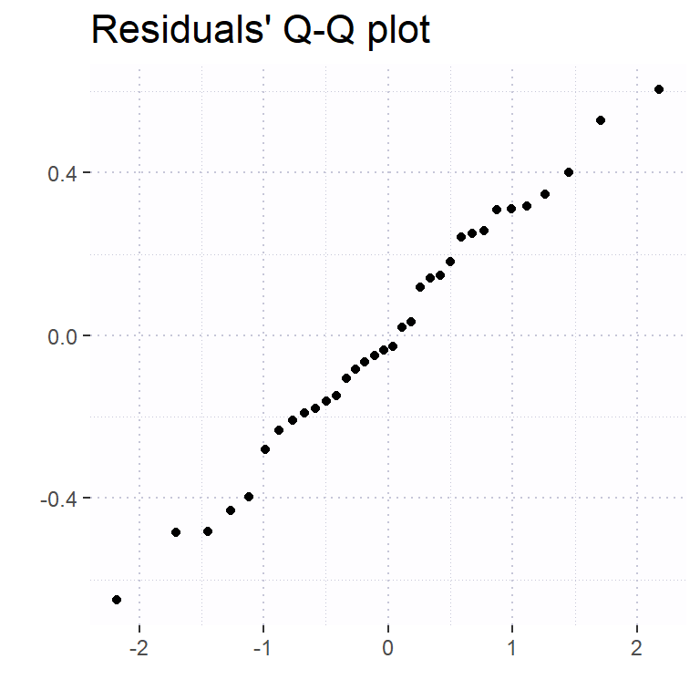

```r
# q-q plot
model_residuals %>%
  ggplot()+
  geom_qq(mapping = aes(sample = values))+
  theme_graph()+
  labs(title = "Residuals' Q-Q plot",
       x = "",
       y = "")
```

Este gráfico também aponta para a ideia de resíduos normalmente distribuídos. Apesar de estes métodos serem bons e práticos, as vezes é necessário usar métodos formais para gerar alguma conclusão. Para validação da independência no comportamento dos resíduos pode-se usar o teste **Durbin Watson**. O código abaixo realiza este teste.

```r
# Necessário instalar e chamar o pacote 'lmtest'
lmtest::dwtest(df %>%
                 lm(formula = log(area) ~ log(price)))
```

```
##
##  Durbin-Watson test
##
## data:  df %>% lm(formula = log(area) ~ log(price))
## DW = 1.2912, p-value = 0.009801
## alternative hypothesis: true autocorrelation is greater than 0
```

**DL** = 1.35

**DU** = 1.49